# Twitter Sentiment Analysis

- This notebook demonstrates how we built our algorithm and tests it for accuracy.
- Towards the end of this notebook is a simulation of our Tweet & Eat algorithm and how we expect it to perform within our web app.

```python
from nltk.corpus import twitter_samples
from nltk.corpus import stopwords
stop_words = stopwords.words('english')
from nltk.stem.wordnet import WordNetLemmatizer  # Lemmatize text (running=run)
from nltk.tag import pos_tag  # Assign positional tags to tokens (noun, verb, adjective)
import re, string  # Filter regular expressions
from nltk import NaiveBayesClassifier  # Classifier algorithm
from nltk import classify  # Classify tweets as positive or negative
from nltk import FreqDist  # Determine the most frequent words in analysis
from nltk.tokenize import word_tokenize
import random
import math
import pandas as pd
import matplotlib.pyplot as plt
import numpy as np
import tweepy
import warnings
warnings.filterwarnings("ignore")
from config import api_key, secret_api_key, access_token, secret_access_token
import os
os.system('jupyter nbconvert --to html sentimate_analysis-html.ipynb')
```

```
0
```

```python
# Viewing json files inside twitter_samples data
twitter_samples.fileids()
```

```
['negative_tweets.json', 'positive_tweets.json', 'tweets.20150430-223406.json']
```

## Understanding our training dataset

- In order to properly train our model, we must begin by understanding our training dataset.
- We also want to be sure our dataset is free of bias.
- To do this, we will compare our Natural Language Toolkit (NLTK) twitter_samples dataset to a real-time, random dataset from Twitter's API.

### Wrangling data from the NLTK corpus

```python
# Joining positive and negative NLTK datasets with desired information
user_created_at = [i["user"]["created_at"] for i in twitter_samples.docs("positive_tweets.json")] + [i["user"]["created_at"] for i in twitter_samples.docs("negative_tweets.json")]
user_language = [i["user"]["lang"] for i in twitter_samples.docs("positive_tweets.json")] + [i["lang"] for i in twitter_samples.docs("negative_tweets.json")]
user_followers_count = [i["user"]["followers_count"] for i in twitter_samples.docs("positive_tweets.json")] + [i["user"]["followers_count"] for i in twitter_samples.docs("negative_tweets.json")]
user_status_count = [i["user"]["statuses_count"] for i in twitter_samples.docs("positive_tweets.json")] + [i["user"]["statuses_count"] for i in twitter_samples.docs("negative_tweets.json")]
user_friend_count = [i["user"]["friends_count"] for i in twitter_samples.docs("positive_tweets.json")] + [i["user"]["friends_count"] for i in twitter_samples.docs("negative_tweets.json")]
user_verified = [i["user"]["verified"] for i in twitter_samples.docs("positive_tweets.json")] + [i["user"]["verified"] for i in twitter_samples.docs("negative_tweets.json")]
corpus_tweets = [i["text"] for i in twitter_samples.docs("positive_tweets.json")] + [i["text"] for i in twitter_samples.docs("negative_tweets.json")]

corpus_df = pd.DataFrame({
    "user_created_at":user_created_at,
    "user_language":user_language,
    "user_followers_count":user_followers_count,
    "user_status_count":user_status_count,
    "user_friend_count":user_friend_count,
    "user_verified":user_verified,
    "tweet":corpus_tweets
})

corpus_df.head()
```

|  | user_created_at | user_language | user_followers_count | user_status_count | user_friend_count | user_verified | tweet |
| --- | --- | --- | --- | --- | --- | --- | --- |
| 0 | Thu Feb 18 13:18:49 +0000 2010 | fr | 3683 | 12858 | 1505 | False | #FollowFriday @France_Inte @PKuchly57 @Milipol... |
| 1 | Mon Feb 09 14:30:33 +0000 2009 | en | 22528 | 13135 | 834 | False | @Lamb2ja Hey James! How odd :/ Please call our... |
| 2 | Mon Aug 23 12:16:57 +0000 2010 | en | 187 | 1335 | 482 | False | @DespiteOfficial we had a listen last night :)... |
| 3 | Tue Jul 24 20:38:16 +0000 2012 | fr | 3231 | 39809 | 1052 | False | @97sides CONGRATS :) |
| 4 | Tue Jul 29 11:52:14 +0000 2014 | en | 398 | 2887 | 56 | False | yeaaaah yippppy!!! my accnt verified rqst has... |

### Wrangling data from the Twitter API

```python
# Establish Twitter API authorization
auth = tweepy.OAuthHandler(api_key, secret_api_key)
auth.set_access_token(access_token, secret_access_token)
api = tweepy.API(auth)

# Collecting tweets - sending request to Twitter's API
response = api.search(q="all",count=100,tweet_mode="extended")

api_df = pd.DataFrame({
    "user_created_at":[i.user.created_at for i in response],
    "user_language":[i.lang for i in response],
    "user_followers_count":[i.user.followers_count for i in response],
    "user_status_count":[i.user.statuses_count for i in response],
    "user_friend_count":[i.user.friends_count for i in response],
    "user_verified":[i.user.verified for i in response],
    "tweet":[i.full_text for i in response]
})

api_df.head()
```

|  | user_created_at | user_language | user_followers_count | user_status_count | user_friend_count | user_verified | tweet |
| --- | --- | --- | --- | --- | --- | --- | --- |
| 0 | 2009-01-17 07:02:45 | en | 269 | 11362 | 1278 | False | RT @jonathanalter: Paging all lawyers who want... |
| 1 | 2019-02-08 04:53:26 | en | 379 | 2910 | 292 | False | RT @ickobel: all I know is pain™ https://t.co/... |
| 2 | 2009-08-31 01:54:16 | en | 196 | 11202 | 685 | False | RT @brettirwin15: Still no cancer meds in the ... |
| 3 | 2015-06-16 11:11:53 | en | 45 | 3391 | 54 | False | RT @saintscommlagos: Note this ..\n\nEven if y... |
| 4 | 2009-08-13 03:09:16 | th | 234 | 8434 | 96 | False | RT @YounaChann: สงสารคนต่างจังหวัดมากนะเอาจริง... |

```python
# Displaying the top 5 languages and their tweet counts
corpus_df["user_language"].value_counts()[:5]
```

```
en       9261
en-gb     171
id        100
fr         96
de         75
Name: user_language, dtype: int64
```

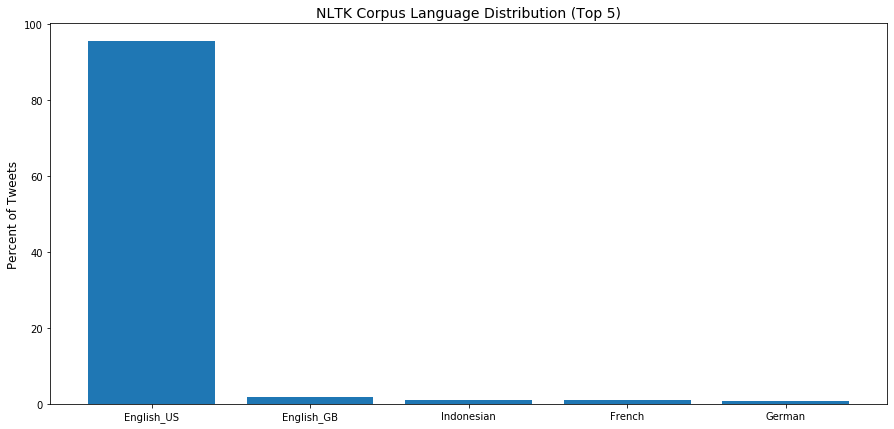

```python
# Converting language counts to percentage
counts = corpus_df["user_language"].value_counts()[:5]
total = counts.sum()
points = []
for i in counts:
    percent = round(i/total*100,2)
    points.append(percent)

# Plotting
labels = ["English_US","English_GB","Indonesian","French","German"]
plt.figure(figsize=(15,7))
plt.bar(np.arange(5),points)
plt.xticks(np.arange(5),labels)
plt.title("NLTK Corpus Language Distribution (Top 5)", size=14)
plt.ylabel("Percent of Tweets",size=12)
plt.show()
```

## Understanding the model's vocabulary

- As displayed in the chart above, our training data is largely composed of English tweets.
- Knowing this, we can conclude that we must pass our model English tweets for an accurate result.
- If we pass the model tweets in any other language, it will not understand; therefore becoming unreliable.

```python
# Calculating means across corpus and real-time tweets
api_avg_followers = api_df["user_followers_count"].mean()
corpus_avg_followers = corpus_df["user_followers_count"].mean()
api_avg_statuses = api_df["user_status_count"].mean()
corpus_avg_statuses = corpus_df["user_status_count"].mean()
api_avg_friend_count = api_df["user_friend_count"].mean()
corpus_avg_friend_count = corpus_df["user_friend_count"].mean()
api_avg_user_verified = len(api_df.loc[api_df["user_verified"]=="True"])
corpus_avg_user_verified = len(corpus_df.loc[corpus_df["user_verified"]=="True"])
api = [api_avg_followers,api_avg_statuses,api_avg_friend_count,api_avg_user_verified]
corpus = [corpus_avg_followers, corpus_avg_statuses, corpus_avg_friend_count, corpus_avg_user_verified]
```

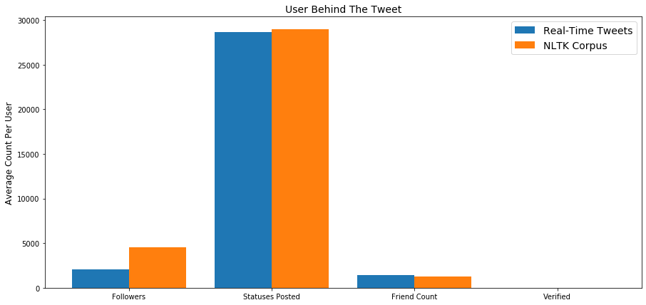

```python
# Plotting
x_values = np.arange(4)
labels = ["Followers","Statuses Posted","Friend Count","Verified"]
width = 0.4
plt.figure(figsize=(15,7))
plt.bar(x_values, api , width, label="Real-Time Tweets")
plt.bar(x_values + width, corpus, width, label="NLTK Corpus")
plt.xticks(x_values+width/2,labels)
plt.legend(loc="best",prop={'size': 14})
plt.ylabel("Average Count Per User", size=12)
plt.title("User Behind The Tweet",size=14)
plt.show()
```

## Getting to know the user

- In this chart, we are comparing profile characteristics of tweet authors in both our NLTK and randomly selected Twitter dataset.
- The similar distribution of user profile characteristics suggest our training data accuratly describes our randomly selected twitter data's user profile characteristics.

```python
# Converting tweets into one large string value
api_tweets = api_df['tweet'].str.lower().str.cat(sep=' ')
corpus_tweets = corpus_df['tweet'].sample(100).str.lower().str.cat(sep=' ')

# Normalizing the data
stop_words=set(stopwords.words('english'))
api_tokenize=word_tokenize(api_tweets)
corpus_tokenize=word_tokenize(corpus_tweets)

# Filtering punctuation, numbers, spaces, etc
api_alpha_tokenize=[word for word in api_tokenize if word.isalpha()]
corpus_alpha_tokenize=[word for word in corpus_tokenize if word.isalpha()]

# Filtering stop words and 'rt'
api_filtered_tokenize=[word for word in api_alpha_tokenize if not word in stop_words and word != "rt"]
corpus_filtered_tokenize=[word for word in corpus_alpha_tokenize if not word in stop_words and word != "rt"]
```

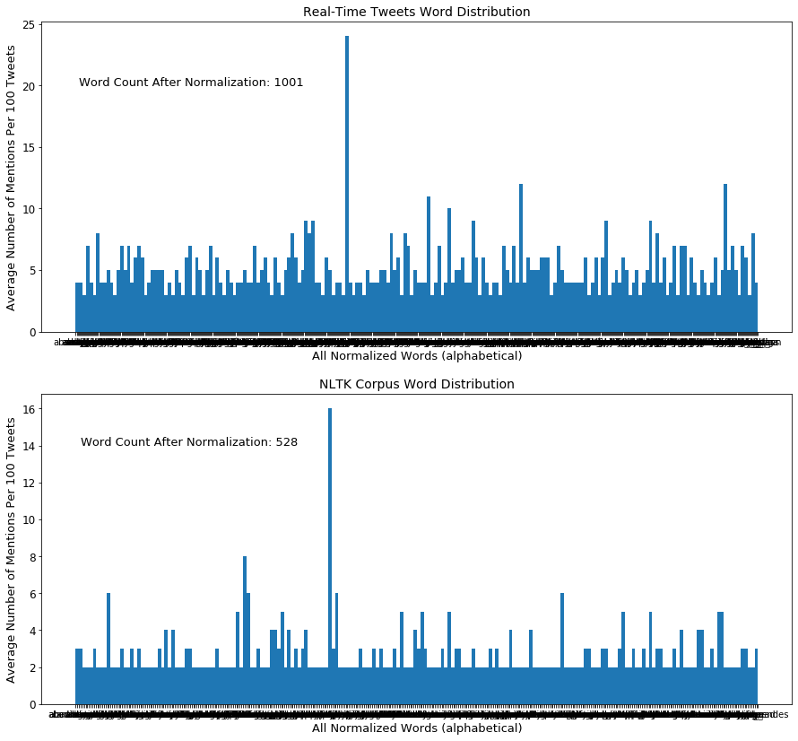

```python
fig, [ax1,ax2] = plt.subplots(2,1, figsize=(15,14))
# twitter api
ax1.hist(sorted(api_filtered_tokenize), bins=200)
ax1.set_title("Real-Time Tweets Word Distribution",size=14)
ax1.set_ylabel("Average Number of Mentions Per 100 Tweets",size=13)
ax1.set_xlabel("All Normalized Words (alphabetical)",size=13)
ax1.tick_params(axis='y', which='major', labelsize=12)
ax1.text(3, 20, f"Word Count After Normalization: {len(api_filtered_tokenize)}",fontsize=13)
# ax1.axhline(5,color='black',ls='-')

# corpus
ax2.hist(sorted(corpus_filtered_tokenize), bins=200)
ax2.set_title("NLTK Corpus Word Distribution",size=14)
ax2.set_ylabel("Average Number of Mentions Per 100 Tweets",size=13)
ax2.set_xlabel("All Normalized Words (alphabetical)",size=13)
ax2.tick_params(axis='y', which='major', labelsize=12)
ax2.text(3, 14, f"Word Count After Normalization: {len(corpus_filtered_tokenize)}",fontsize=13)
# ax2.axhline(5,color='black',ls='-')
plt.show()
```

## Word frequency distribution

- The above charts show the distribution of words across both datasets.
- Similar distributions, with limited skewness, indicates a lower chance of bias in the NLTK training dataset.

```python
# Function to remove undesired text from tokens (puncuation, numbers & symbols, stop words)
def clean_data(tweet_tokens, stop_words = ()):

    cleaned_tokens = []

    for token, tag in pos_tag(tweet_tokens):
        # Removing unwanted symbols and patterns from tokens using regular expressions
        token = re.sub("http[s]?://(?:[a-zA-Z]|[0-9]|[$-_@.&+#]|[!*\(\),]|(?:%[0-9a-fA-F][0-9a-fA-F]))+","", token)
        token = re.sub("(@[A-Za-z0-9_]+)","", token)

        # Assigning new position tags for WordNetLemmatizer() function
        if tag.startswith("NN"):
            pos = "n"
        elif tag.startswith("VB"):
            pos = "v"
        else:
            pos = "a"

        # Lemmatizing tokens (running=run)
        lemmatizer = WordNetLemmatizer()
        token = lemmatizer.lemmatize(token, pos)

        # Dropping puncuation and stop words
        if len(token) > 0 and token not in string.punctuation and token.lower() not in stop_words:
            cleaned_tokens.append(token.lower())
    return cleaned_tokens

# Function to covert a list to a dictionary with keys=tokens and values=true
def get_tweets_for_model(cleaned_tokens_list):
    for tweet_tokens in cleaned_tokens_list:
        yield dict([token, True] for token in tweet_tokens)
```

## Training the NaiveBayesClassifier algorithm

- Now that we are satisfied with our NLTK dataset, we can use it to train our model.
- We begin by cleaning our data, before properly formatting it and shuffling it into two seperate datasets.
- One dataset will be used to train the model and the other will be used to test for accuracy once the training is complete.

### Tokenizing, cleaning and assembling the dataset

```python
# Tokenizing positive/negative tweets
positive_tokens = twitter_samples.tokenized("positive_tweets.json")
negative_tokens = twitter_samples.tokenized("negative_tweets.json")

# Cleaning and prepping tokens for analysis
positive_cleaned_tokens_list = []
negative_cleaned_tokens_list = []
for tokens in positive_tokens:
    positive_cleaned_tokens_list.append(clean_data(tokens, stop_words))
for tokens in negative_tokens:
    negative_cleaned_tokens_list.append(clean_data(tokens, stop_words))
```

```python
# Converting lists of tokens to dictionaries with keys=tokens and values=True
positive_tokens_for_model = get_tweets_for_model(positive_cleaned_tokens_list)
negative_tokens_for_model = get_tweets_for_model(negative_cleaned_tokens_list)

# Creating dataset with assigned positive and negative setiment values
positive_dataset = [(tweet_dict, "Positive") for tweet_dict in positive_tokens_for_model]
negative_dataset = [(tweet_dict, "Negative") for tweet_dict in negative_tokens_for_model]

# Combining and shuffling positive and negative datasets
dataset = positive_dataset + negative_dataset
random.shuffle(dataset)

# Splitting dataset into train/test data
train_data = dataset[:7000]
test_data = dataset[7000:]
```

### Training and testing the NaiveBayesClassifier

```python
# Training the NaiveBayesClassifier algorithm
classifier = NaiveBayesClassifier.train(train_data)
# Assessing the accuracy of the algorithm
print("Accuracy is:", classify.accuracy(classifier, test_data))
# Displaying the most informative words
print(classifier.show_most_informative_features(10))
```

```
Accuracy is: 0.9973333333333333
Most Informative Features
                      :) = True           Positi : Negati =    984.0 : 1.0
                     sad = True           Negati : Positi =     56.5 : 1.0
                followed = True           Negati : Positi =     23.1 : 1.0
                follower = True           Positi : Negati =     22.1 : 1.0
                     bam = True           Positi : Negati =     20.3 : 1.0
                  friday = True           Positi : Negati =     16.1 : 1.0
               community = True           Positi : Negati =     15.6 : 1.0
                      aw = True           Negati : Positi =     14.4 : 1.0
              appreciate = True           Positi : Negati =     14.3 : 1.0
                   didnt = True           Negati : Positi =     13.7 : 1.0
None
```

## Understanding the results

- After passing the *training* dataset to our algorithm, we tested it for accuracy with our *testing* dataset.
- We can see that our algorithm **correctly classified 99.7%** of all tweets in our testing dataset. We like that reading!
- We can also see the training dataset's most informative words and their positive/negative ratios.
- **Example Reading:** For every one negative tweet that contained ':)', 984 positive tweets also contained ':)'.

### Testing the NaiveBayesClassifier on custom text

```python
custom_tweet = "That chicken alfredo was WOW!!"

custom_tokens = clean_data(word_tokenize(custom_tweet))
result = classifier.classify(dict([token, True] for token in custom_tokens))
result
```

```
'Positive'
```

# Live Twitter Sentiment Analysis

#### This section of the notebook is a simulation of our Tweet & Eat algorithm and how we expect it to perform within our web app.

- It will return a 'sentiment score' for any given topic provided at random by the user.
- Since we are not opting to pay for access to larger datasets at this time, we will run this simulation with 100 real-time tweets posted within the last seven days.

```python
# Establish Twitter API authorization
auth = tweepy.OAuthHandler(api_key, secret_api_key)
auth.set_access_token(access_token, secret_access_token)
api = tweepy.API(auth)

# Ask the user for topic of analysis, in this case we are analyzing "cheesecake factory"
user_input = input("Enter the name of the topic to analyze for sentimate :")
if user_input == "":
    user_input = input("Enter the name of the topic to analyze for sentimate :")
    if user_input == "":
        exit()

# Request the twitter api
total_tweet_count = 100
response = api.search(q=user_input,count=total_tweet_count,tweet_mode="extended",lang="en",result_type="mixed") #result_type=mixed, recent, popular
```

```
Enter the name of the topic to analyze for sentimate :cheesecake factory
```

```python
# Tally positive and negative results based on the NaiveBayesClassifier's decision
positive_result=0
negative_result=0
positive_tweets = []
negative_tweets = []
for tweet in response:
    tweet_text = tweet.full_text
    tweet_tokens = clean_data(word_tokenize(tweet_text))
    result = classifier.classify(dict([token, True] for token in tweet_tokens))
    if result == "Negative":
        negative_result += 1
        negative_tweets.append(tweet.full_text)
    elif result == "Positive":
        positive_result += 1
        positive_tweets.append(tweet.full_text)
print(f"Positive results: {positive_result}")
print(f"Negative results: {negative_result}")
```

```
Positive results: 74
Negative results: 26
```

## Calculating the sentiment score

- The sentimate score is calculated using the formula *sentimate_score = (number of positive results / number of tweets analyzed) x 5*
- We also display examples of tweets classified as positive and negative by the algorithm

```python
# Calculate sentiment score
sentiment_score = round((positive_result/total_tweet_count) * 5,2)
print(f"""'{user_input.title()}' scores a {sentiment_score} out of 5.
""")
print(f"""Positive Tweet Example: '{random.choice(positive_tweets)}'
""")
print(f"Negative Tweet Example: '{random.choice(negative_tweets)}'")
```

```
'Cheesecake Factory' scores a 3.7 out of 5.

Positive Tweet Example: '@PCRCEPTlON i’m goin to the cheesecake factory for my birthday in 13 days ♡'

Negative Tweet Example: 'I refer to The Cheesecake Factory as “Cheesecake” like that’s all ain’t nobody got time to be saying all them words 😂'
```